# Onboarding to a defensive workflow

The minimum elements of a defensive workflow and links to learn more.

Mauro Lepore https://github.com/maurolepore  
2021-10-26

### Table of Contents

This article overviews the minimum elements of a defensive workflow and points you to resources to learn more ([video](https://youtu.be/YlBnarQNRR8)). Beyond onboarding to 2DII, this article should be useful if you suspect you’ve drifted into habits that slow you down or make your work more brittle (https://rstats.wtf/).

### [Setup RStudio to start from a blank slate every time you restart R](https://rstats.wtf/save-source.html)

Use these settings:

- Save workspace on quit: Never[^1].
- Load workspace on start: Off.

Restart your R session often to confirm you can reproduce your results from a blank slate.

### [Use RStudio projects](https://rstats.wtf/project-oriented-workflow.html#rstudio-projects)

RStudio makes it easy to create new projects[^2] and launch recent projects[^3]. To launch older projects it’s easiest to use a dedicated app like Alfred[^4].

### [Practice safe paths](https://rstats.wtf/safe-paths.html)

Find your project’s files with `here()`.

> Use it as a drop-in replacement for `file.path()`, it will always locate the files relative to your project root. – https://here.r-lib.org/reference/here.html

```r
library(here)

# Good
(path <- here("_posts", "2021-10-26-defensive-workflow", "data", "greeting.txt"))
```

```
#> [1] "/home/rstudio/2degreesinvesting.github.io/_posts/2021-10-26-defensive-workflow/data/greeting.txt"
```

```r
readLines(path)
```

```
#> [1] "Hello world"
```

```r
# Bad
(path <- "/a/brittle path/that/only/i/have/data/greeting.txt")
```

```
#> [1] "/a/brittle path/that/only/i/have/data/greeting.txt"
```

```r
readLines(path)
```

```
#> Error in file(con, "r"): cannot open the connection
```

### [How to name files](https://rstats.wtf/how-to-name-files.html)

Name your files following these guidelines:

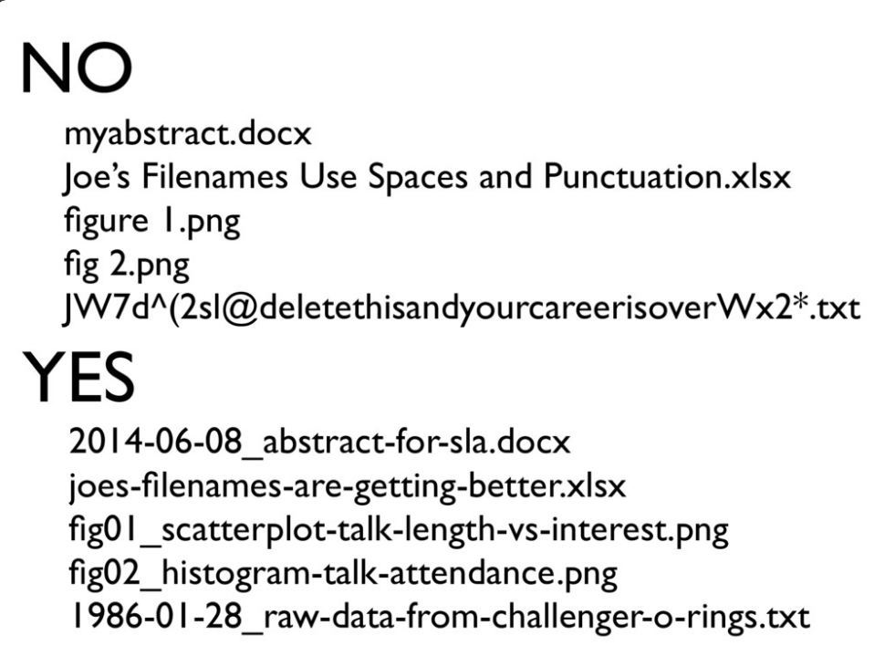

https://speakerdeck.com/jennybc/how-to-name-files

[^1]: Shift + Ctrl/Cmd + P

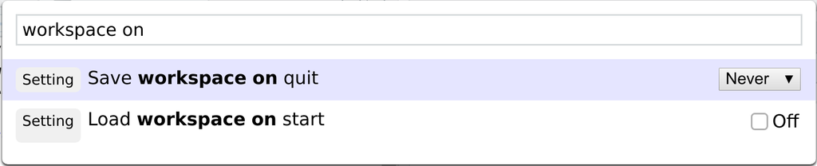

[^2]: File > New Project
[^3]: File > Recent Projects

[figure not shown]